```python
name_subj = "S8"

import mne
import os
import numpy as np
import pandas as pd
import matplotlib.pyplot as plt

%matplotlib inline
EEG_data_path = './'#Path data is
```

# Reading raw BDF, setting up bipolar references and montage

```
Extracting EDF parameters from /home/gweindel/owncloud/projects/supervisions/2023/Kenneth_contrast/EEG_data/raw/S8.bdf...
BDF file detected
Setting channel info structure...
Creating raw.info structure...
Reading 0 ... 2779135  =      0.000 ...  2713.999 secs...
Effective window size : 2.000 (s)
```

```
[Parallel(n_jobs=1)]: Using backend SequentialBackend with 1 concurrent workers.
[Parallel(n_jobs=1)]: Done   1 out of   1 | elapsed:    4.4s remaining:    0.0s
[Parallel(n_jobs=1)]: Done   1 out of   1 | elapsed:    4.4s finished
```

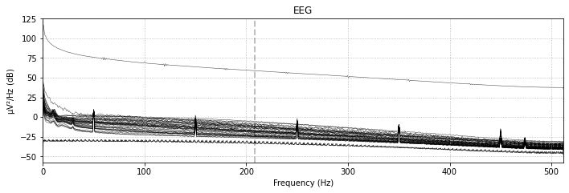

| Measurement date | March 30, 2023 13:35:58 GMT |
| --- | --- |
| Experimenter | Unknown |
| Digitized points | Not available |
| Good channels | 41 EEG, 1 Stimulus |
| Bad channels | None |
| EOG channels | Not available |
| ECG channels | Not available |
| Sampling frequency | 1024.00 Hz |
| Highpass | 0.00 Hz |
| Lowpass | 208.00 Hz |

```python
raw = mne.io.read_raw_bdf(EEG_data_path+'raw/%s.bdf'%name_subj,preload=True, verbose=True)
raw.plot_psd(tmin=500, picks='eeg');
plt.show()
raw.info
```

```python
raw.drop_channels(['EXG6','EXG7','EXG8'])#Empty

# Creating the bipolar montage, the 4 first are the EOG
mne.set_bipolar_reference(raw,anode=['EXG1','EXG3'],cathode=['EXG2','A1'],ch_name=['EOGH','EOGV'],copy=False, drop_refs=False)
raw.set_channel_types({'EOGH':'eog','EOGV':'eog','EXG4':'misc','EXG5':'misc','Erg1':'misc',
                      'EXG1':'misc','EXG2':'misc','EXG3':'misc','EXG4':'misc'})#declare type to avoid confusion with EEG channels
#Renaming electrodes
dict_to_biosemi = dict(zip(raw.copy().pick_types(eeg=True).ch_names, mne.channels.make_standard_montage('biosemi32').ch_names))
raw.rename_channels(dict_to_biosemi)
raw.set_montage('biosemi32')
```

```
EEG channel type selected for re-referencing
Creating RawArray with float64 data, n_channels=2, n_times=2779136
    Range : 0 ... 2779135 =      0.000 ...  2713.999 secs
Ready.
Added the following bipolar channels:
EOGH, EOGV
```

| Measurement date | March 30, 2023 13:35:58 GMT |
| --- | --- |
| Experimenter | Unknown |
| Digitized points | 35 points |
| Good channels | 32 EEG, 6 misc, 1 Stimulus, 2 EOG |
| Bad channels | None |
| EOG channels | EOGH, EOGV |
| ECG channels | Not available |
| Sampling frequency | 1024.00 Hz |
| Highpass | 0.00 Hz |
| Lowpass | 208.00 Hz |
| Filenames | S8.bdf |
| Duration | 00:45:13 (HH:MM:SS) |

# Checking for bad electrodes

```python
%matplotlib qt
raw.set_eeg_reference('average')#For electrode check
raw.plot(block=True, n_channels=74, scalings=100e-6);
```

```
EEG channel type selected for re-referencing
Applying average reference.
Applying a custom ('EEG',) reference.
Using matplotlib as 2D backend.
Channels marked as bad:
['P4']
```

Additionally it is possible to check bridged electrode but with 32 electrodes that is unlikely

```python
raw.info['bads']
```

```
['P4']
```

## REST reference

```python
# Setting the reference, REST
sphere = mne.make_sphere_model('auto', 'auto', raw.info, verbose=False)
src = mne.setup_volume_source_space(sphere=sphere, exclude=30., pos=15., verbose=False)
forward = mne.make_forward_solution(raw.info, trans=None, src=src, bem=sphere, verbose=False)
raw.set_eeg_reference('REST', forward=forward)
```

```
EEG channel type selected for re-referencing
Applying REST reference.
Applying a custom ('EEG',) reference.
    31 out of 32 channels remain after picking
```

| Measurement date | maart 30, 2023 13:35:58 GMT |
| --- | --- |
| Experimenter | Unknown |
| Digitized points | 35 points |
| Good channels | 32 EEG, 6 misc, 1 Stimulus, 2 EOG |
| Bad channels | P4 |
| EOG channels | EOGH, EOGV |
| ECG channels | Not available |
| Sampling frequency | 1024.00 Hz |
| Highpass | 0.00 Hz |
| Lowpass | 208.00 Hz |
| Filenames | S8.bdf |
| Duration | 00:45:13 (HH:MM:SS) |

# Filtering

Low, high pass filter + notchfilter at 50Hz

```
Filtering raw data in 1 contiguous segment
Setting up band-pass filter from 1 - 1e+02 Hz

FIR filter parameters
---------------------
Designing a one-pass, zero-phase, non-causal bandpass filter:
- Windowed time-domain design (firwin) method
- Hamming window with 0.0194 passband ripple and 53 dB stopband attenuation
- Lower passband edge: 1.00
- Lower transition bandwidth: 1.00 Hz (-6 dB cutoff frequency: 0.50 Hz)
- Upper passband edge: 100.00 Hz
- Upper transition bandwidth: 25.00 Hz (-6 dB cutoff frequency: 112.50 Hz)
- Filter length: 3381 samples (3.302 sec)
```

```
[Parallel(n_jobs=1)]: Using backend SequentialBackend with 1 concurrent workers.
[Parallel(n_jobs=1)]: Done   1 out of   1 | elapsed:    0.1s remaining:    0.0s
[Parallel(n_jobs=1)]: Done   2 out of   2 | elapsed:    0.2s remaining:    0.0s
[Parallel(n_jobs=1)]: Done   3 out of   3 | elapsed:    0.3s remaining:    0.0s
[Parallel(n_jobs=1)]: Done   4 out of   4 | elapsed:    0.4s remaining:    0.0s
```

```
Setting up band-stop filter from 49 - 51 Hz

FIR filter parameters
---------------------
Designing a one-pass, zero-phase, non-causal bandstop filter:
- Windowed time-domain design (firwin) method
- Hamming window with 0.0194 passband ripple and 53 dB stopband attenuation
- Lower passband edge: 49.38
- Lower transition bandwidth: 0.50 Hz (-6 dB cutoff frequency: 49.12 Hz)
- Upper passband edge: 50.62 Hz
- Upper transition bandwidth: 0.50 Hz (-6 dB cutoff frequency: 50.88 Hz)
- Filter length: 6759 samples (6.601 sec)
```

```
[Parallel(n_jobs=1)]: Done  32 out of  32 | elapsed:    3.0s finished
[Parallel(n_jobs=1)]: Using backend SequentialBackend with 1 concurrent workers.
[Parallel(n_jobs=1)]: Done   1 out of   1 | elapsed:    0.1s remaining:    0.0s
[Parallel(n_jobs=1)]: Done   2 out of   2 | elapsed:    0.2s remaining:    0.0s
[Parallel(n_jobs=1)]: Done   3 out of   3 | elapsed:    0.3s remaining:    0.0s
[Parallel(n_jobs=1)]: Done   4 out of   4 | elapsed:    0.4s remaining:    0.0s
[Parallel(n_jobs=1)]: Done  32 out of  32 | elapsed:    3.1s finished
```

```
Effective window size : 2.000 (s)
```

```
[Parallel(n_jobs=1)]: Using backend SequentialBackend with 1 concurrent workers.
[Parallel(n_jobs=1)]: Done   1 out of   1 | elapsed:    2.1s remaining:    0.0s
[Parallel(n_jobs=1)]: Done   1 out of   1 | elapsed:    2.1s finished
```

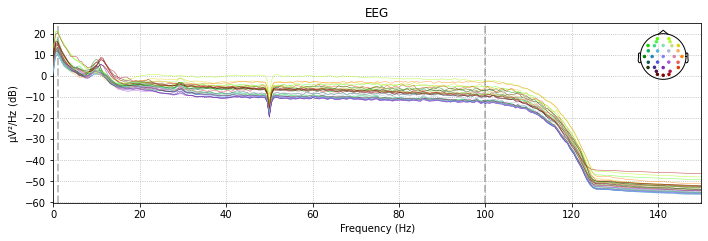

```python
%matplotlib inline
raw.filter(1, 100, None,l_trans_bandwidth='auto',filter_length='auto',phase='zero') #Filtering between 1 and 100 Hz
raw.notch_filter(freqs=50)#In this experiment 50Hz for all participants so notch filter needed
raw.plot_psd(tmin=500, fmax=150, picks='eeg');
plt.show()
```

I save the data, hence saving the montage, the low-pass filtered data, the (eventual) annotation of the bad channel

```python
raw.save(EEG_data_path+"preprocessing/pre_rejection_%s.fif"%name_subj,overwrite=True) #sauvegarde les données au format fif pour la suite des traitements
```

```
Overwriting existing file.
Writing /home/gweindel/owncloud/projects/supervisions/2023/Kenneth_contrast/EEG_data/preprocessing/pre_rejection_S8.fif
```

```
Closing /home/gweindel/owncloud/projects/supervisions/2023/Kenneth_contrast/EEG_data/preprocessing/pre_rejection_S8.fif
[done]
```

# Rejecting artefacts

```python
events = mne.find_events(raw)
```

```
Trigger channel has a non-zero initial value of 65536 (consider using initial_event=True to detect this event)
4465 events found
Event IDs: [    3     4     5     6     7     8     9    10    11    12    13    14
    15    16    17    18    19    20    21    22    23    24    25    26
    27    28    29    30    31    32    33    34    35    36    37    38
    39    40    41    42    43    44    45    46    47    48    49    50
    51    52    53    54    55    56    57    58    59    60    61    62
    63    64    65    66    67    68    69    70    71    72    73    74
    75    76    77    78    79    80    81    82    83    84    85    86
    87    88    89    90    91    92    93    94    95    99   100   101
   199   200   201 65790]
```

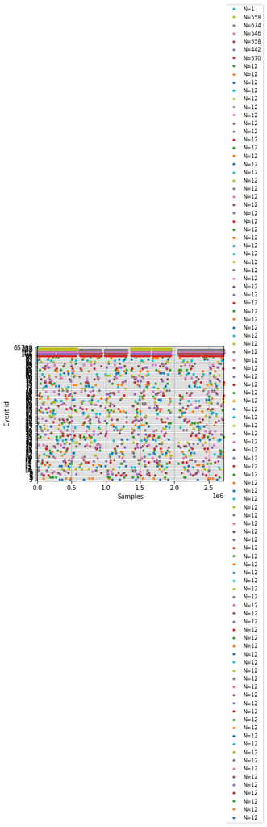

```python
mne.viz.plot_events(events);
```

```python
events[1:11]
```

```
array([[2518,    0,  201],
       [2636,    0,   99],
       [2764,    0,   92],
       [3362,    0,  100],
       [4517,    0,  201],
       [4635,    0,  199],
       [4758,    0,   19],
       [5345,    0,  100],
       [6903,    0,  201],
       [7021,    0,   99]])
```

```python
all_events = np.array(np.unique(events[:,2]))
stim_trigger = all_events[all_events<99]
conditions_to_trigger = {"acc":101, "spd":201}
side_to_trigger = {"left":99, "right":199}
resp_trigger = [100,200]
```

```python
stim = np.array([x for x in events if x[-1] in  stim_trigger])
resp = np.array([x for x in events if x[-1] in  resp_trigger])

color_dict = {k:'b' for k in stim_trigger}
color_dict.update({k:'g' for k in resp_trigger})
color_dict.update({k:'gray' for k in set.difference(set(all_events),set(stim_trigger), set(resp_trigger))})
```

## Correcting stim onset based on photodiode

```python
def find_onset_pd(data, event_sample, baseline=500):
    '''
    Detects onset of stim through std deviation of photodiode signal
    '''
    try:
        index = np.where(data <0)[0][0]
    except:
        return(event_sample)
    if event_sample - (index-baseline+event_sample) >0:
        print('inconsistent photodiode detected onset')
        return(event_sample)
    else:
        return(index-baseline+event_sample)

len([x[0] for x in events if x[2] in stim_trigger])
```

```
1116
```

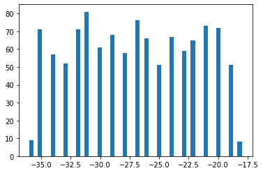

```
1116
```

```python
photodiode = raw.copy().pick(['Erg1']).get_data()[0]
baseline = 500
new_events = events.copy()
onsets = []
for i in np.arange(len(events)):
    if events[i,2] in stim_trigger:
        onsets.append(find_onset_pd(photodiode[events[i,0]-baseline:events[i,0]+150], events[i,0], baseline=baseline))
        new_events[i,0] = onsets[-1]
%matplotlib inline
diffs = events[:,0] - new_events[:,0]
diffs = diffs[diffs != 0]
plt.hist(diffs,bins=50);
plt.show()
print(sum(events[:,0] != new_events[:,0]))
```

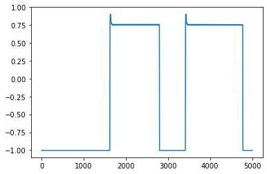

```python
plt.plot(photodiode[:5000])
```

```python
events = new_events
raw.add_events(events, replace=True)
```

# ICA

## Preparing for ICA

### Annotation of very long RTs/breaks

```python
stim_events = np.array([list(x) for x in events if x[2] in stim_trigger])


estimated_duration_breaks = 6 #seconds
onset_breaks = stim_events[np.where(np.diff(stim_events[:,0], n=1) > (raw.info['sfreq']*estimated_duration_breaks))][:,0]/raw.info['sfreq'] #detecting latencies between triggers > x sec
offset_breaks = np.flip(np.flip(stim_events)[np.where(np.diff(np.flip(stim_events[:,0]), n=1) < -(raw.info['sfreq']*estimated_duration_breaks))])[:,0]/raw.info['sfreq']

onset_breaks = onset_breaks + 3 #add 3 sec after last stimulus trigger
offset_breaks = offset_breaks - .6 #removes 600 msec before next stimulus trigger

onset_breaks = np.insert(onset_breaks,0,0)#just adding start of the recording to the breaks
onset_breaks = np.insert(onset_breaks,-1, stim_events[-1,0]/raw.info['sfreq']+3)#just adding end of the recording to the breaks

offset_breaks = np.insert(offset_breaks,0,stim_events[0,0]/raw.info['sfreq']-.6)#just adding start of the recording to the breaks
offset_breaks = np.insert(offset_breaks,-1, raw.times.max())#just adding end of the recording to the breaks


duration_breaks = np.asarray(offset_breaks) - np.asarray(onset_breaks)


print(len(duration_breaks))
break_annot = mne.Annotations(onset= np.insert(onset_breaks,0,0),#just adding start of the recording to the breaks
                           duration=np.insert(duration_breaks,0, stim_events[0,0]/raw.info['sfreq']-1),
                           description=['BAD_breaks'])
raw.set_annotations(break_annot)
```

```
9
```

| Measurement date | maart 30, 2023 13:35:58 GMT |
| --- | --- |
| Experimenter | Unknown |
| Digitized points | 35 points |
| Good channels | 32 EEG, 6 misc, 1 Stimulus, 2 EOG |
| Bad channels | P4 |
| EOG channels | EOGH, EOGV |
| ECG channels | Not available |
| Sampling frequency | 1024.00 Hz |
| Highpass | 1.00 Hz |
| Lowpass | 100.00 Hz |
| Filenames | S8.bdf |
| Duration | 00:45:13 (HH:MM:SS) |

## Adding annotations

First enter in annotation mode with ctrl+A and add a description "BAD" then remove portions where participant was clearly doing something else (scratching, blinking during stimulus presentation, weird artifacts), also remoe trials with unrecoverable noise and spread across all electrodes

```python
%matplotlib qt
if 'saved_annotations_%s.csv'%(name_subj) in os.listdir('preprocessing'):
    annot_from_file = mne.read_annotations('preprocessing/saved_annotations_%s.csv'%(name_subj))
    raw.set_annotations(annot_from_file)
    raw.plot(events=events,  event_color=color_dict, remove_dc=True, n_channels=len(raw.ch_names), use_opengl=True, block=True)
    raw.annotations.save('preprocessing/saved_annotations_%s.csv'%(name_subj),overwrite=True)
else:
    raw.plot(events=events,  event_color=color_dict, remove_dc=True, n_channels=len(raw.ch_names), use_opengl=True, block=True)
    raw.annotations.save('preprocessing/saved_annotations_%s.csv'%(name_subj),overwrite=True)
```

```
Channels marked as bad:
['P4']
Overwriting existing file.
```

[output not shown]

```python
raw.save("preprocessing/pre_ica_%s.fif"%name_subj,overwrite=True)
```

```
Overwriting existing file.
Writing /home/gweindel/owncloud/projects/supervisions/2023/Kenneth_contrast/EEG_data/preprocessing/pre_ica_S8.fif
```

```
Closing /home/gweindel/owncloud/projects/supervisions/2023/Kenneth_contrast/EEG_data/preprocessing/pre_ica_S8.fif
[done]
```

## For the remaining sections and up to the ICA reconstruction I only work with 1Hz High pass filtered data

```python
raw = mne.io.read_raw_fif(EEG_data_path+"preprocessing/pre_ica_%s.fif"%name_subj, preload=True)
```

```
Opening raw data file ./preprocessing/pre_ica_S8.fif...
    Range : 0 ... 2779135 =      0.000 ...  2713.999 secs
Ready.
Reading 0 ... 2779135  =      0.000 ...  2713.999 secs...
```

# Fitting ICA

### Resampling

Downsampling to 500 Hz to reduce computational load.

```python
events = mne.find_events(raw)
raw, events = raw.resample(500, events=events)
```

```
4465 events found
Event IDs: [    3     4     5     6     7     8     9    10    11    12    13    14
    15    16    17    18    19    20    21    22    23    24    25    26
    27    28    29    30    31    32    33    34    35    36    37    38
    39    40    41    42    43    44    45    46    47    48    49    50
    51    52    53    54    55    56    57    58    59    60    61    62
    63    64    65    66    67    68    69    70    71    72    73    74
    75    76    77    78    79    80    81    82    83    84    85    86
    87    88    89    90    91    92    93    94    95    99   100   101
   199   200   201 65790]
```

```python
all_events = np.array(np.unique(events[:,2]))
stim_trigger = all_events[all_events<99]
conditions_to_trigger = {"acc":101, "spd":201}
side_to_trigger = {"left":99, "right":199}
resp_trigger = [100,200]
```

```python
ica = mne.preprocessing.ICA(n_components = len(raw.pick_types(eeg=True).ch_names)-1, method='fastica', max_iter='auto')
ica.fit(raw)
```

```
Fitting ICA to data using 31 channels (please be patient, this may take a while)
Omitting 184987 of 1357000 (13.63%) samples, retaining 1172013 (86.37%) samples.
Fitting ICA took 64.7s.
```

| Method | fastica |
| --- | --- |
| Fit | 49 iterations on raw data (1172013 samples) |
| ICA components | 30 |
| Explained variance | 100.0 % |
| Available PCA components | 31 |
| Channel types | eeg |
| ICA components marked for exclusion | — |

```python
ica.save("preprocessing/ICA_object_%s.fif"%name_subj, overwrite=True);
```

```
Overwriting existing file.
Writing ICA solution to /home/gweindel/owncloud/projects/supervisions/2023/Kenneth_contrast/EEG_data/preprocessing/ICA_object_S8.fif...
```

### Visualizing on epochs

```python
epochs = mne.Epochs(raw, stim, event_id=[int(x) for x in stim_trigger], tmin=-0.5, tmax=2, preload=True)
```

```
Not setting metadata
1116 matching events found
Setting baseline interval to [-0.5, 0.0] sec
Applying baseline correction (mode: mean)
0 projection items activated
Using data from preloaded Raw for 1116 events and 1251 original time points ...
613 bad epochs dropped
```

### ICs epoch timecourse

```python
%matplotlib qt
ica.plot_components(inst=epochs)
```

```
[<MNEFigure size 702x696 with 20 Axes>, <MNEFigure size 702x357 with 10 Axes>]
```

```
    Using multitaper spectrum estimation with 7 DPSS windows
Not setting metadata
503 matching events found
No baseline correction applied
0 projection items activated
```

```
Not setting metadata
503 matching events found
No baseline correction applied
0 projection items activated
```

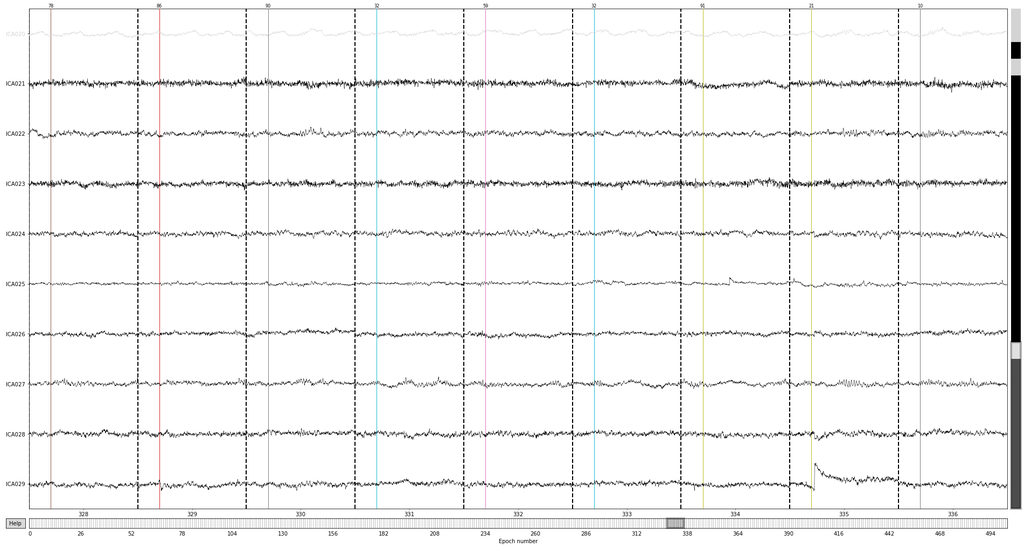

```python
ica.plot_sources(epochs, block=True)
```

### zoom on suspsicious ICs

```
    Using multitaper spectrum estimation with 7 DPSS windows
Not setting metadata
503 matching events found
No baseline correction applied
0 projection items activated
    Using multitaper spectrum estimation with 7 DPSS windows
Not setting metadata
503 matching events found
No baseline correction applied
0 projection items activated
    Using multitaper spectrum estimation with 7 DPSS windows
Not setting metadata
503 matching events found
No baseline correction applied
0 projection items activated
    Using multitaper spectrum estimation with 7 DPSS windows
Not setting metadata
503 matching events found
No baseline correction applied
0 projection items activated
```

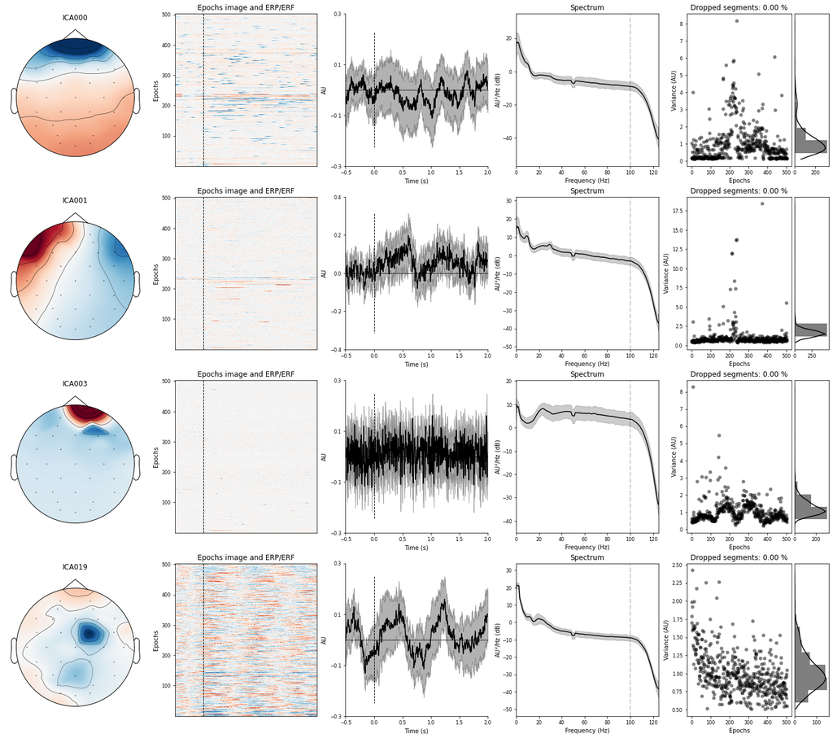

```python
%matplotlib inline
fig, ax = plt.subplots(len(ica.exclude), 5, figsize = (25, len(ica.exclude)*5))
i = 0
for comp in ica.exclude:
    ica.plot_properties(epochs, picks=comp, axes=ax[i,:], show=False);
    i += 1
plt.show()
ica.exclude = [int(x) for x in input([]).split(',')]
```

```python
ica.exclude = [0,1,3]
```

## Final exclusions of ICA components :

```
[0, 1, 3]
Applying ICA to Evoked instance
    Transforming to ICA space (30 components)
    Zeroing out 3 ICA components
    Projecting back using 31 PCA components
```

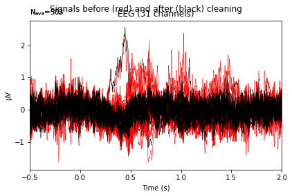

```python
%matplotlib inline
print(ica.exclude)
ica.plot_overlay(epochs.average(), exclude=ica.exclude, picks='eeg');
```

```python
raw = mne.io.read_raw_fif(EEG_data_path+"preprocessing/pre_ica_%s.fif"%name_subj, preload=True)
```

```
Opening raw data file ./preprocessing/pre_ica_S8.fif...
    Range : 0 ... 2779135 =      0.000 ...  2713.999 secs
Ready.
Reading 0 ... 2779135  =      0.000 ...  2713.999 secs...
```

```python
ica.apply(raw)
```

```
Applying ICA to Raw instance
    Transforming to ICA space (30 components)
    Zeroing out 3 ICA components
    Projecting back using 31 PCA components
```

| Measurement date | maart 30, 2023 13:35:58 GMT |
| --- | --- |
| Experimenter | Unknown |
| Digitized points | 35 points |
| Good channels | 32 EEG, 6 misc, 1 Stimulus, 2 EOG |
| Bad channels | P4 |
| EOG channels | EOGH, EOGV |
| ECG channels | Not available |
| Sampling frequency | 1024.00 Hz |
| Highpass | 1.00 Hz |
| Lowpass | 100.00 Hz |
| Filenames | pre_ica_S8.fif |
| Duration | 00:45:13 (HH:MM:SS) |

## Interpolating the bad electrodes after ICA

```python
print(raw.info['bads'])
raw = raw.interpolate_bads()
raw.info['bads']
```

```
['P4']
Interpolating bad channels
    Automatic origin fit: head of radius 95.0 mm
Computing interpolation matrix from 31 sensor positions
Interpolating 1 sensors
```

```
[]
```

```
Setting 378859 of 2779136 (13.63%) samples to NaN, retaining 2400277 (86.37%) samples.
Effective window size : 2.000 (s)
```

```
[Parallel(n_jobs=1)]: Using backend SequentialBackend with 1 concurrent workers.
[Parallel(n_jobs=1)]: Done   1 out of   1 | elapsed:    3.4s remaining:    0.0s
[Parallel(n_jobs=1)]: Done   1 out of   1 | elapsed:    3.4s finished
```

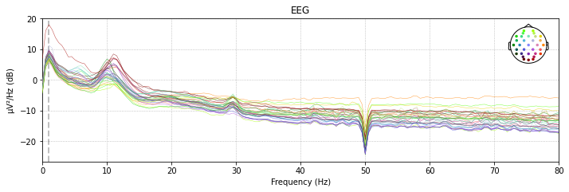

```python
raw.plot_psd(fmax=80);
```

```python
raw.save("preprocessing/post_ica_%s_raw.fif"%name_subj,overwrite=True)
```

```
Writing /home/gweindel/owncloud/projects/supervisions/2023/Kenneth_contrast/EEG_data/preprocessing/post_ica_S8_raw.fif
Closing /home/gweindel/owncloud/projects/supervisions/2023/Kenneth_contrast/EEG_data/preprocessing/post_ica_S8_raw.fif
[done]
```

# Auto-reject remaining artifacts

## Creating epochs

```python
trig_id = dict(zip([str(x) for x in np.unique(stim[:, -1])],np.unique(stim[:, -1])))
epochs = mne.Epochs(raw, stim, event_id=trig_id, tmin=-0.5, tmax=3, preload=True, baseline=None)
```

```
Not setting metadata
1116 matching events found
No baseline correction applied
0 projection items activated
Using data from preloaded Raw for 1116 events and 3585 original time points ...
13 bad epochs dropped
```

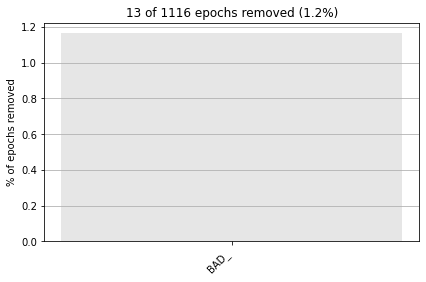

```python
epochs.plot_drop_log();
```

## Auto-reject on remaining artifacts

```python
import autoreject #version 0.3.1 https://autoreject.github.io/
ar = autoreject.AutoReject(consensus=np.linspace(0, .5, 11), n_jobs=-1) #I constrain the consensus parameter to be <=.5 as trials with more than half bad chan should be rejected
ar.fit(epochs)  # fit on the first 20 epochs to save time
epochs_ar, reject_log = ar.transform(epochs, return_log=True)
```

```
Running autoreject on ch_type=eeg
```

```
  0%|          | Creating augmented epochs : 0/32 [00:00<?,       ?it/s]
```

```
  0%|          | Computing thresholds ... : 0/32 [00:00<?,       ?it/s]
```

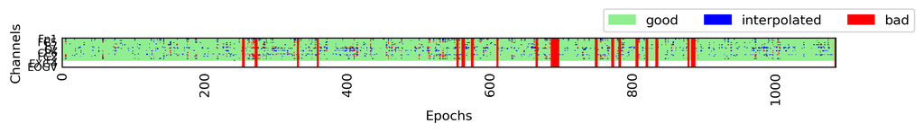

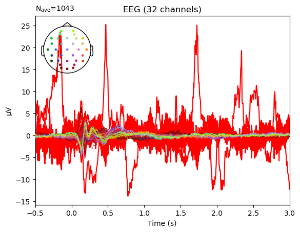

```python
%matplotlib inline
fig, ax = plt.subplots(1,1, figsize=(10,20), dpi=300)
reject_log.plot('horizontal', ax=ax)
plt.show()
evoked_bad = epochs[reject_log.bad_epochs].average()
plt.figure()
plt.plot(evoked_bad.times, evoked_bad.data.T * 1e6, 'r', zorder=-1)
epochs_ar.average().plot(axes=plt.gca());
```

Checking results and rejecting some more epochs (if any)

Rejected epochs

```python
%matplotlib qt
reject_log.plot_epochs(epochs,scalings=dict(eeg=100e-6))
```

```
<mne_qt_browser._pg_figure.MNEQtBrowser at 0x7f335413a200>
```

```
Dropped 13 epochs: 57, 142, 152, 176, 187, 188, 262, 267, 268, 275, 276, 277, 292
The following epochs were marked as bad and are dropped:
[66, 162, 176, 200, 211, 212, 293, 298, 299, 306, 307, 308, 323]
Channels marked as bad:
none
```

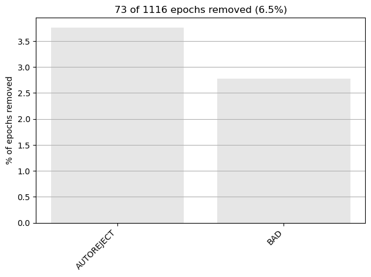

```python
epochs_ar.plot_drop_log()
```

```python
epochs_ar.save('preprocessed/%s_epo.fif'%name_subj, overwrite=True)
```